# R_ATP_ggplot

余采蘋

2018年10月3日

## ATP網球選手分析:

```r
zip.file <- "TennisData_ATP.zip"

if (!file.exists(zip.file)){
  download.file('https://github.com/JeffSackmann/tennis_atp/archive/master.zip', destfile = zip.file)
}

dir.out <- 'tennis_atp-master/'
if (!dir.exists(dir.out)) unzip(zip.file)

#列出目錄/文件夾的檔案
Tennis.file <- list.files(dir.out, pattern = '*.csv', full.names = T)
print(Tennis.file)
```

```
##   [1] "tennis_atp-master/atp_matches_1968.csv"
##   [2] "tennis_atp-master/atp_matches_1969.csv"
##   [3] "tennis_atp-master/atp_matches_1970.csv"
##   [4] "tennis_atp-master/atp_matches_1971.csv"
##   [5] "tennis_atp-master/atp_matches_1972.csv"
##   [6] "tennis_atp-master/atp_matches_1973.csv"
##   [7] "tennis_atp-master/atp_matches_1974.csv"
##   [8] "tennis_atp-master/atp_matches_1975.csv"
##   [9] "tennis_atp-master/atp_matches_1976.csv"
##  [10] "tennis_atp-master/atp_matches_1977.csv"
##  [11] "tennis_atp-master/atp_matches_1978.csv"
##  [12] "tennis_atp-master/atp_matches_1979.csv"
##  [13] "tennis_atp-master/atp_matches_1980.csv"
##  [14] "tennis_atp-master/atp_matches_1981.csv"
##  [15] "tennis_atp-master/atp_matches_1982.csv"
```

[output cut: 99 more lines]

從上一個結果可以看出zip裡面不只有match還有rankings，但是我只有要用有match的文件，所以用stringr來處理

```r
library(readr)
library(dplyr)
library(stringr)
Tennis.mfile <- Tennis.file[str_detect(Tennis.file, "match")]
```

讀取資料，設定cols

```r
Tennis.col <- cols(
  .default = col_integer(),
  tourney_id = col_character(),
  tourney_name = col_character(),
  surface = col_character(),
  tourney_level = col_character(),
  winner_name = col_character(),
  winner_ioc = col_character(),
  winner_age = col_integer(),
  loser_name = col_character(),
  loser_ioc = col_character(),
  loser_age = col_integer(),
  score = col_character(),
  round = col_character()
)
```

運用do.call & lapply處理資料

```r
df.tennisMatches <- do.call(bind_rows, lapply(Tennis.mfile, read_csv, col_types = Tennis.col))
df.tennisMatches$Date <- as.Date(as.character(df.tennisMatches$tourney_date), '%Y%m%d')
df.tennisMatches$Years <- format(df.tennisMatches$Date, format= "%Y")
```

搜尋網路上ATP排名前100名的選手

```r
library(xml2)
library(rvest)
res <- read_html("https://www.atpworldtour.com/en/rankings/singles")
top100.players <- res %>% html_nodes(".player-cell a") %>% html_text()

top3.name <- top100.players[1:3]
```

只求前3名的選手名

```r
top3.name <- top100.players[1:3]
```

從data frame中找出跟網站上名字最相近的字 由於web上目前排名14的阿根挺籍選手Diego Schwartzman，在CSV中顯示為Diego Sebastian Schwartzman。 藉由amatch找出相近字串這個方法會一直跑出另一個Diego Sxxxxxx的選手， 因此我用手動調整csv檔，將所有的Diego Sebastian Schwartzman replace by Diego Schwartzman。

```r
library(stringdist)
player.name <- unique(c(df.tennisMatches$winner_name, df.tennisMatches$loser_name))
similar.name <- amatch(top3.name,player.name, maxDist = 3 )
data.frame(name.from.web = top3.name, name.from.csv = player.name[similar.name])
```

```
##    name.from.web  name.from.csv
## 1   Rafael Nadal   Rafael Nadal
## 2  Roger Federer  Roger Federer
## 3 Novak Djokovic Novak Djokovic
```

```r
top3.name <- player.name[similar.name]
```

運用tibble可以更方便使用dplyr 讀取前3名

```r
Tennis.table <- tibble()
for( my.player in top3.name){
  perc <- filter(df.tennisMatches, (winner_name==my.player)|(loser_name==my.player))
  perc$Name <- my.player
  perc.tab <- perc %>% group_by(Name, Years, surface) %>% summarise("Percentage of win" = sum(winner_name== Name)/n(),
                                 "Number of matches" = n()) %>%
    filter("Number of matches" > 0) %>%
    filter(surface %in% c("Grass","Clay"))
  Tennis.table <- bind_rows(Tennis.table,perc.tab)
}
```

加入ranking

```r
Tennis.table$Name <- paste0(Tennis.table$Name,
                          '(',
                          match(Tennis.table$Name, top3.name),
                          ')')
Tennis.table <- Tennis.table[complete.cases(Tennis.table),]
Tennis.table
```

```
## # A tibble: 101 x 5
##    Name            Years surface `Percentage of win` `Number of matches`
##    <chr>           <chr> <chr>                 <dbl>               <int>
##  1 Rafael Nadal(1) 2001  Clay                  0.615                  13
##  2 Rafael Nadal(1) 2002  Clay                  0.769                  52
##  3 Rafael Nadal(1) 2003  Clay                  0.75                   32
##  4 Rafael Nadal(1) 2003  Grass                 0.667                   3
##  5 Rafael Nadal(1) 2004  Clay                  0.778                  18
##  6 Rafael Nadal(1) 2005  Clay                  0.962                  52
##  7 Rafael Nadal(1) 2005  Grass                 0.333                   3
##  8 Rafael Nadal(1) 2006  Clay                  1                      26
##  9 Rafael Nadal(1) 2006  Grass                 0.8                    10
## 10 Rafael Nadal(1) 2007  Clay                  0.969                  32
## # ... with 91 more rows
```

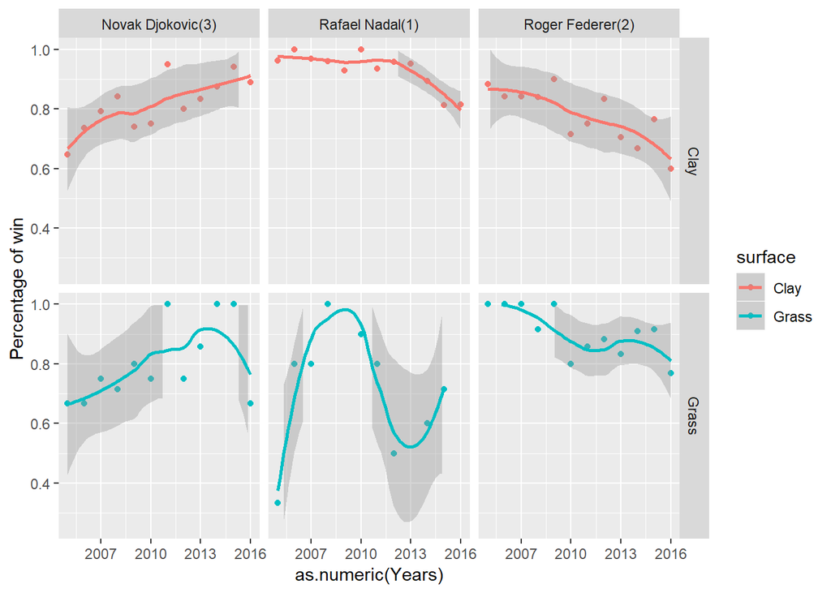

```r
library(ggplot2)

p <- ggplot(Tennis.table, aes(x = as.numeric(Years), y = `Percentage of win`, color=surface))
p <- p + geom_point() + geom_smooth()
p <- p + facet_grid(surface~Name)
p <- p + ylim(c(0.25,1)) + xlim(c(2005,2016))
print(p)
```

```r
my.favplayer.w <- subset(df.tennisMatches, winner_name=="Novak Djokovic", select = c(surface))
my.favplayer.l <- subset(df.tennisMatches,loser_name=="Novak Djokovic", select = c(surface))
```

將輸及贏的場地用rbind結合，算出不同場地材質的比賽總次數 依照不同場地材質(贏次數 / 總次數) = 獲勝機率

```r
total.df <- rbind(my.favplayer.w, my.favplayer.l)

perc.df <- as.data.frame(table(my.favplayer.w) / table(total.df) )
colnames(perc.df) <- c("surface","percentage")
```

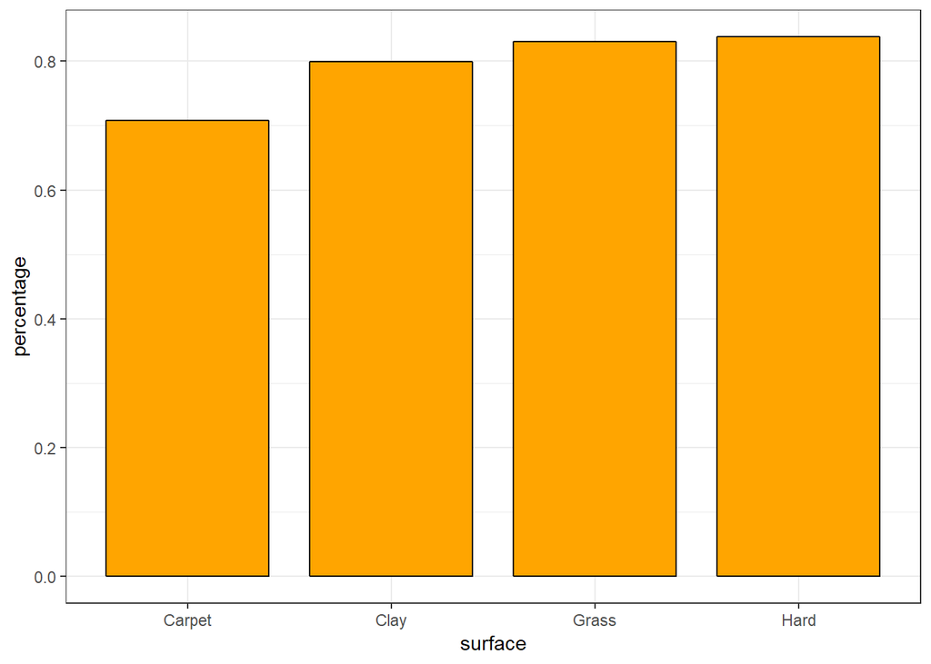

```r
library(ggrepel)
p.per <- ggplot(perc.df, aes(surface, percentage))+geom_bar(stat='identity',colour="black",  fill= "orange",width = 0.8)+
  theme_bw()
print(p.per)
```

```r
#library
library(xml2)
library(rvest)
library(stringr)
library(readr)
library(dplyr)
```

讀取csv檔

```r
Tennis2018.source <- read.csv("file:///C:/Users/user/Desktop/NTU_COOL/week_3/R_ATP_ggplot/tennis_atp-master/atp_matches_2018.csv")
```

運用sebset選出winner_name, loser_name, winner_ioc, loser_ioc 將col名字改為一樣，用rbind連接，並使用unique

```r
subset.1 <- subset(Tennis2018.source, select = c(winner_name, winner_ioc))
subset.2 <- subset(Tennis2018.source, select = c(loser_name, loser_ioc))
colnames(subset.1) <- c("name", "country")
colnames(subset.2) <- c("name", "country")
subset.d <- rbind(subset.1, subset.2)
subset.d <- unique(subset.d)
s <- as.data.frame(table(subset.d$country))
colnames(s) <- c("country", "count")
```

```r
s <- s[order(s$count),]
s.select <- s[72:80,]
```

做圖，藍色長條圖 運用geom_text，數據以白色呈現列出選手數量

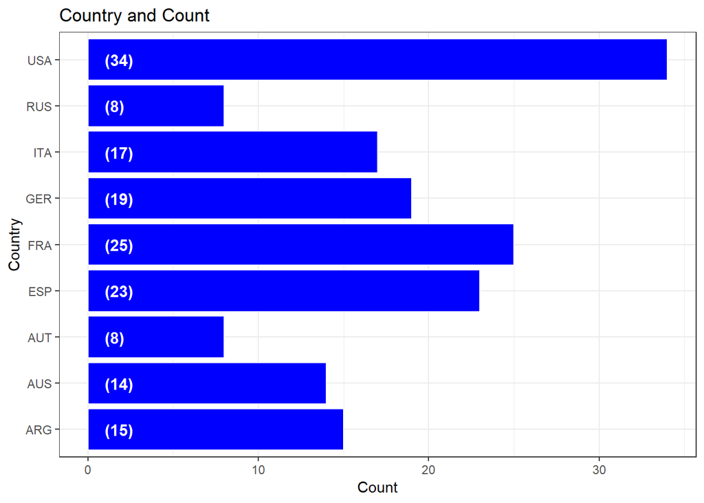

```r
ioc.p <- ggplot(s.select ,aes(x = country, y = count)) +  geom_bar(stat='identity',colour="white",  fill= "blue")+coord_flip() + theme_bw()+
  geom_text(aes(x = country, y = 1, label = paste0("(",count,")",sep="")),
            hjust=0, vjust=.5, size = 4,
            colour = 'white',fontface = 'bold')+
  labs(x = 'Country', y = 'Count',
       title = 'Country and Count')
print(ioc.p)
```